# ESM 204 HW 4

Author

Dustin Duncan

```r
rm(list = ls())
library(tidyverse)
library(pracma)
library(stats)
```

**Reading in Data**

```r
warming <- read.csv("data/warming.csv")
```

## 1 Question 1

*Plot damage function over a range of Delta T values from 0-6 degrees C*

### 1.1 Damage function:

$$\mathrm{damages = -2.05e^{12}(\triangle{T}) + 3.9e^{13}(\triangle{T^2})}$$
### Implementing damage function as function and plotting

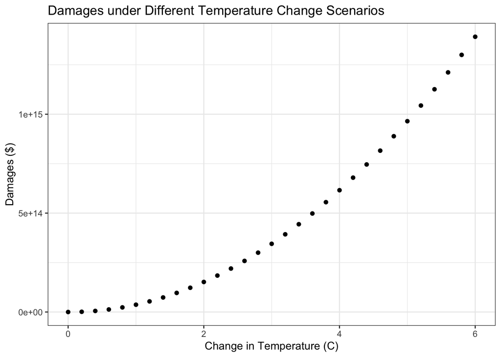

```r
## Writing function to calculate the expected damages (for a given year) under different changes in temperature relative to pre-industrial period (deltaT's)
damage <- function(deltaT){
  damages = ((-2.05*10^(12))*deltaT + (3.9*10^(13))*(deltaT^2))
  return(tibble(dT = deltaT, damages=damages))
}
## Sequencing a range of deltaT values
temp = seq(from=0,to=6, by=0.2)

## Testing it out an seeing if it does what I want. The value should be equivalent to 6th hard value term minus the first hard value term (deltaT = 1)
test <- damage(temp)
## Obtaining my calculation
value_func = test[6,]$damages
## calculating it myself
value_calc = ((-2.05*10^(12)) + (3.9*10^(13)))
## Subtracting the two to make sure their difference is zero
# value_func-value_calc ## Success

## Plotting damages over a range of deltaT values
ggplot(test, aes(x = dT, y = damages)) +
  geom_point() +
  theme_bw() +
  labs(x = "Change in Temperature (C)", y = "Damages ($)") +
  ggtitle("Damages under Different Temperature Change Scenarios")
```

## 2 Question 2

*Predict damages in each year under the baseline and pulse scenarios*

**Modifying Damage function to answer 2.1 and 2.2**

```r
## Taking a brief look at the dataframe
# head(warming)

## Modifying my above damage function to predict changes in each year under the baseli
damage_df <- function(df){ # Function takes df as an input
  year = df$year # Maintaining year from the dataframe so i dont have to cbind
  wbl = df$warming_baseline # Same with warming_baseline and warming_pulse
  wpl = df$warming_pulse


  damages_base = ((-2.05*10^(12))*df$warming_baseline + (3.9*10^(13))*(df$warming_baseline^2)) # Calculating damages under for each year, based off of the change from pre-industrial era (warming_baseline)
  damages_pulse = ((-2.05*10^(12))*df$warming_pulse + (3.9*10^(13))*(df$warming_pulse^2)) # Calculating the same thing as above but for the pulse change from pre-industrial era (warming_pulse)

  ## Then all of these are going back into a dataframe so I should have everything I need to answer questions 2.1 and 2.2
  return(tibble(year = year, warming_baseline = wbl, damages_base=damages_base, warming_pulse = wpl, damages_pulse = damages_pulse))
}
## Using my function on the warming df and storing the resulting df in test2
test2 = damage_df(warming)
```

### 2.1 2.1 Damages over time without the pulse

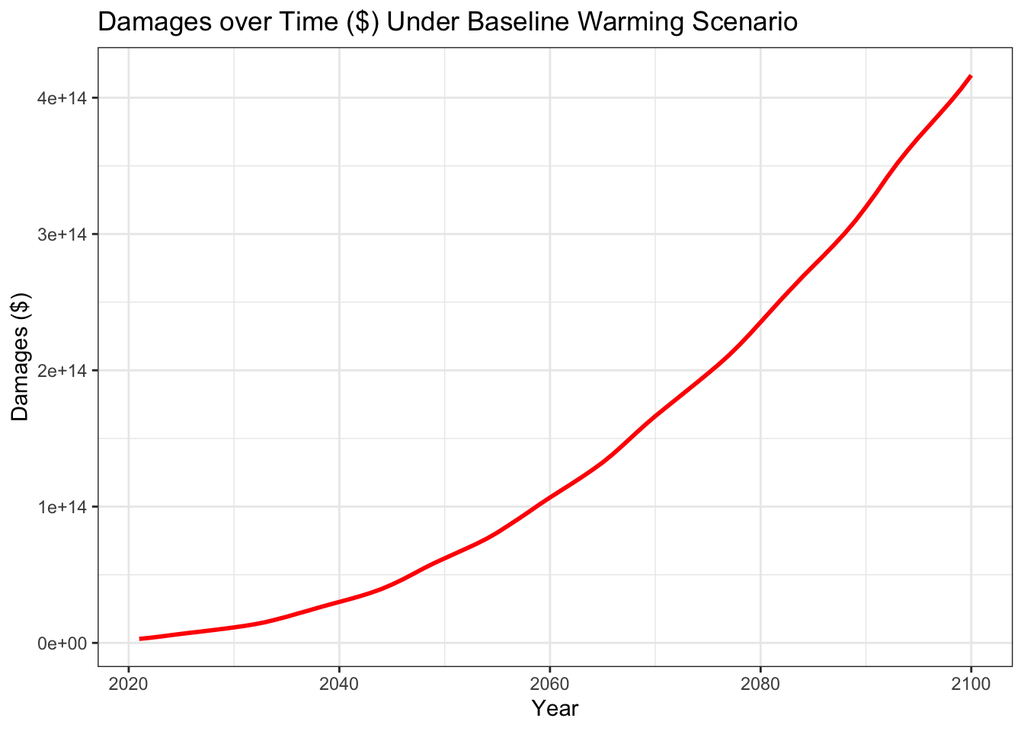

```r
## Just plotting damages over time without the pulse. Basic ggplot
ggplot(test2, aes(year, damages_base)) +
  geom_line(linewidth = 1, color = "red") +
  theme_bw() +
  labs(x = "Year", y = "Damages ($)") +
  ggtitle("Damages over Time ($) Under Baseline Warming Scenario")
```

### 2.2 2.2 Damages over time with pulse

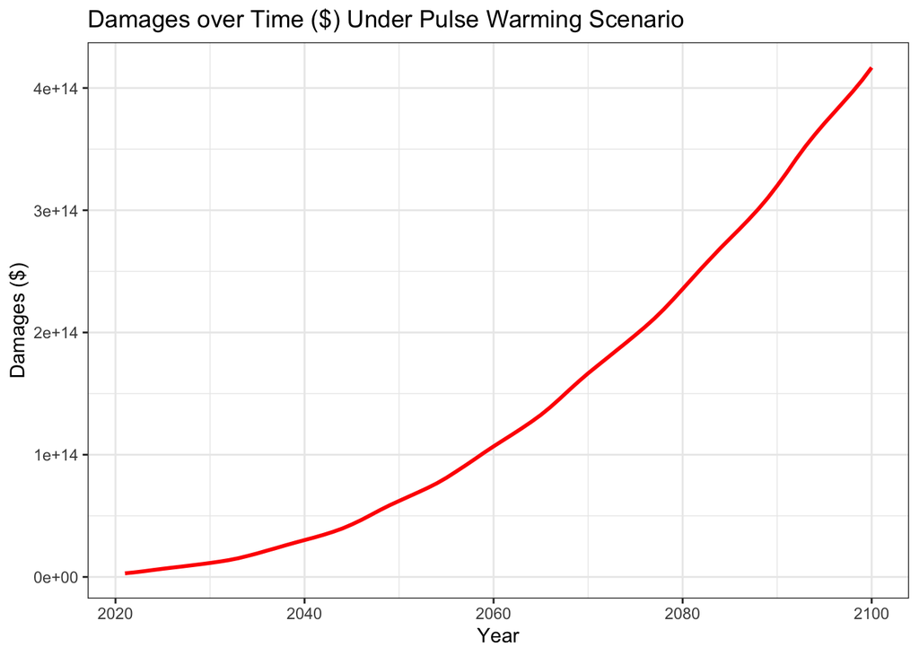

```r
## Doing the same thing as above but with the pulse
ggplot(test2, aes(year, damages_pulse)) +
  geom_line(linewidth = 1, color = "red") +
  theme_bw() +
  labs(x = "Year", y = "Damages ($)") +
  ggtitle("Damages over Time ($) Under Pulse Warming Scenario")
```

### 2.3 2.3 The difference in damages over time with vs without pulse

Damages that arise from the pulse. If I take the difference between my damages_base and damages_pulse columns, that would calculate the pointwise difference in damages, but what about the overall difference in damages?

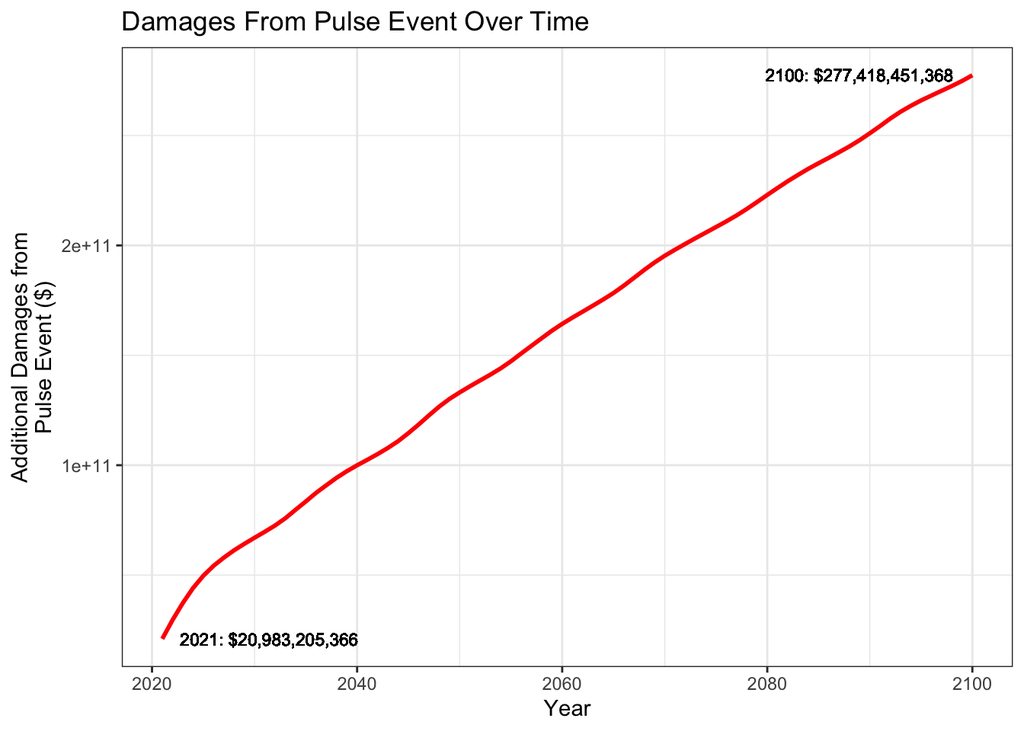

```r
## Creating a new column in my test2 df that is the difference between pulse and baseline damages.
test2$difference = test2$damages_pulse-test2$damages_base

# Wow its actually a pretty sizeable number

## Plotting it over time
ggplot(test2, aes(year, difference)) +
  geom_line(linewidth = 1, color = "red") +
  theme_bw() +
  geom_text(aes(x = 2021, y = 20983205366), label = "2021: $20,983,205,366", size = 3, hjust = -0.1) +
  geom_text(aes(x = 2100, y = 277418451368), label = "2100: $277,418,451,368", size = 3, hjust = 1.1) +
  labs(x = "Year", y = "Additional Damages from\nPulse Event ($)") +
  ggtitle("Damages From Pulse Event Over Time")
```

### 2.4 2.4 Damages over time that arise from the pulse per ton of CO2

If the total amount of CO2 in the pulse was 35,000,000,000 tons, I can divide the total damages (difference column) from the pulse by the tons of CO2 to get damages per ton. This is assuming that each ton is associated with the same amount of damage

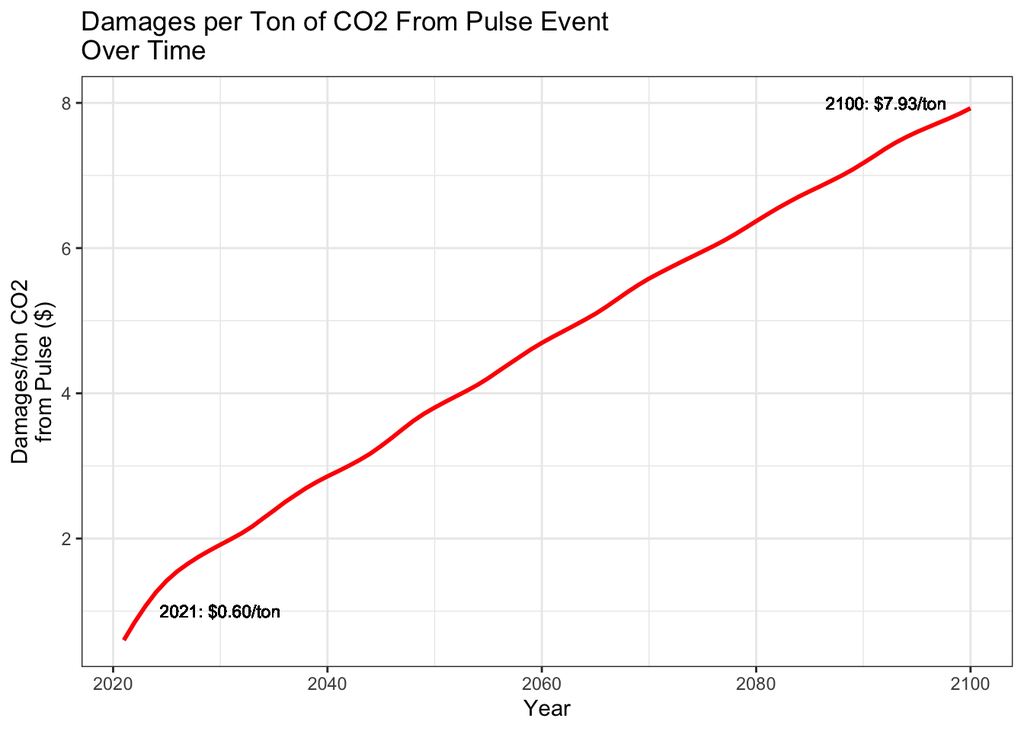

```r
## Creating a new column in my test2 dataframe that will be the difference divided by the total damages (35 billion tons)
test2$diff_per_ton = test2$difference/35000000000

## now plotting damages over time that arise from pulse per ton of CO2
ggplot(test2, aes(year, diff_per_ton)) +
  geom_line(color="red", linewidth=1) +
  geom_text(aes(x = 2021, y = 1), label = "2021: $0.60/ton", size = 3, hjust = -0.3) +
  geom_text(aes(x = 2100, y = 8), hjust= 1.2, label = "2100: $7.93/ton", size = 3) +
  theme_bw() +
  labs(x= "Year", y = "Damages/ton CO2\nfrom Pulse ($)") +
  ggtitle("Damages per Ton of CO2 From Pulse Event\nOver Time")
```

## 3 Question 3

*Calculate and make a plot of the SCC against discount rates from 1-8%*

**Future Value**

$$\mathrm{V_t=V_0(1+r)^t}$$

**Present Value**

$$\mathrm{V_0=\frac{V_t}{(1+r)^t}}$$

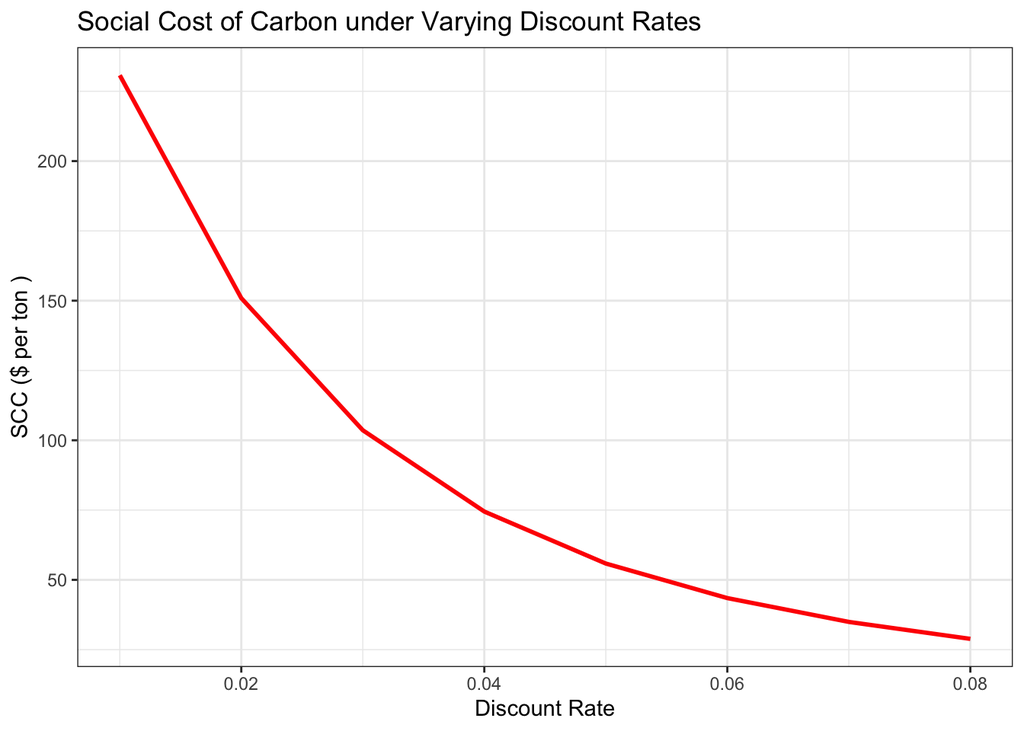

```r
## Writing a function to calculate the net present value at different discount rates, and allow me to change the number of years

pv_calc <- function(rate, time, damages){
  pv = damages/((1+rate)^time)
  return(pv)
}

## Testing my pv_calc on the test2 dataframe difference. This will also serve as a check to my pmapped values for SCC under different discount rates.
presentvalue <- test2 %>%
  mutate(pv = pv_calc(rate=0.02, damages=diff_per_ton, time=year-2021))

## summing it up, After coming back to this dataframe I checked that the SCC for this scenario under dr=2%, that it is the same as the one I calculated using pmap. Moving onwards
scc_simplecase = presentvalue %>%
  mutate(SCC = sum(pv, na.rm = TRUE))

####### This code came from Mauricio's Week 8 Section code example ##########

## Sequencing discount rates to calculate over. Sequencing by 0.01 to get a smoother plot
r <- seq(from=.01, to = .08, by = 0.01)

## Setting list of parameter values for pmap to use
parms <- list(r = r, damages=list(presentvalue$diff_per_ton), time = list(presentvalue$year-2021))

## Using pmap to run my function over different discount rates using the difference
presentvalue_variable_discount <- pmap(parms, ~ data.frame(r = ..1, pv = pv_calc(..1, ..3, ..2), year = presentvalue$year))

## Turning it into a dataframe
presentvalue_variable_discount = bind_rows(presentvalue_variable_discount)

## Summing npv over different discount rates to get the SCC

scc = presentvalue_variable_discount %>%
  group_by(r) %>%
  dplyr::summarise(scc = sum(pv, na.rm = TRUE))

## Calculating present value using function with sequenced r's as discount rates (in units of %) and year 79 as the year 2100

## Plotting
ggplot(scc) +
  geom_line( aes(x = r, y = scc), color = "red", linewidth = 1) +
  theme_bw() +
  labs(x = "Discount Rate", y = "SCC ($ per ton )") +
  ggtitle("Social Cost of Carbon under Varying Discount Rates ")
```

## 4 Question 4

*Now suppose two possible climate policies that can be pursued*

- *Policy A: BAS - Either “Baseline” Warming (p=0.5), or 1.5x(“Baseline”) (p=0.5)*
- *Policy B: Action - Continue under “Baseline” until 2050, then stabilize at 1.29 degrees and stay that way forever*
- *Society is risk neutral*
- *Discount Rate of 2%*

### 4.1 Expected present value of damages up to 2100 under policy A AND B

```r
## Since Policy A and Policy B have unique damage functions that are different from above, I will need to re-write the damage function so as to account for them, and additionally calculate the NPV from each

utility <- function(df, pvfunction){

  ### Calculating damages under for each year, based off of the change from pre-industrial era for policy A optinos (0.5 probability for each)
  ## First option (a1)
  damages_a1 = (-2.05*10^(12))*df$warming_baseline + (3.9*10^(13))*(df$warming_baseline^2)

  ## Second option (a2)
  damages_a2 = ((-2.05*10^(12))*(1.5*df$warming_baseline) + (3.9*10^(13))*((1.5*df$warming_baseline)^2))

  ### Calculating damages for each year based off change for Policy B
  ## If the year is below or equal to 2050
  damages_b = ifelse(df$year <= 2050,
        ## Then the warming continues as it would in the baseline
        (-2.05*10^(12))*df$warming_baseline+(3.9*10^(13))*(df$warming_baseline^2),
        ## Once it hits 2050 it will stabilize and stay that way forever
                     (-2.05*10^(12))*1.29 + (3.9*10^(13))*(1.29^2))


  ### Calculating net present values of either policy
  ## A1
  pv_a1 = pvfunction(rate=0.02, damages=damages_a1, time=df$year-2021)
  ## Sum it
  npv_a1 = sum(pv_a1
               )
  ## A2
  pv_a2 = pvfunction(rate=0.02, damages=damages_a2, time=df$year-2021)
  ## Sum it
  npv_a2 = sum(pv_a2
               )
  ## B
  pv_b = pvfunction(rate=0.02, damages=damages_b, time=df$year-2021)
  ## Sum it
  npv_b = sum(pv_b
              )
  ## Calculating the expected present value considering the probability of either circumstance in Policy A
  Epva = (0.5 * npv_a1) + (0.5 * npv_a2)

  ## Calculating the expected value of Policy B, with certainty
  Epvb = 1 * npv_b

  return(tibble(pva = Epva, pvb = Epvb))
}


## Throw it in a dataframe
test4 <- utility(df=warming, pvfunction=pv_calc)

## Renaming columns for Kable output
colnames(test4) = c("Policy A", "Policy B")

## Throwing it into a kable to make it pretty
knitr::kable(test4, align = "c", caption = "Expected Present Damage Value of Each Policy ($)")
```

Expected Present Damage Value of Each Policy ($)

| Policy A | Policy B |
| --- | --- |
| 6.222156e+15 | 1.596677e+15 |

### 4.2 Suppose Policy A costs nothing to undertake and Policy B costs X. How large could X be for it to still make economic sense to pursue Policy B instead of Policy A?

If Policy A costs nothing to undertake and Policy B costs X, I can use their Expected Net Present Values and add an X term to B to solve for.

$$\mathrm{EV_A = EV_B + X \rightarrow} \\
\mathrm{X = EV_A-EV_B}$$

```r
Evpa = test4$`Policy A`
Evpb = test4$`Policy B`

X = Evpa - Evpb
# X

cat("\'X\' could be up to $", X, "for it to still make economic\nsense to pursue Policy B instead of Policy A")
```

```
'X' could be up to $ 4.62548e+15 for it to still make economic
sense to pursue Policy B instead of Policy A
```

## 5 Question 5

*How would your answer to the above change if society were risk averse? 1-2 sentences*

If society were risk averse, as opposed to risk neutral, their Utility function would be $\mathrm{E[U(x)] < U(E[x])}$, and they would prefer having the expected value with certainty rather than the uncertain value. This indicates that when society is risk averse, they would still prefer policy B for costs up to and greater than $4.62548e+15, but we would need more information about their utility functions to determine the point at which society would prefer policy A.